# Лабораторная работа №1

Установка операционной системы Linux

Липатников Андрей

1032253853@rudn.ru

Российский университет дружбы народов

2026-10-07

# Информация

## Докладчик

- Липатников Андрей
- Студент Российского университета дружбы народов им. П. Лумумбы
- 1032253853@rudn.ru

# Вводная часть

## Актуальность

- Изучение операционных систем требует безопасной и воспроизводимой среды
- Виртуализация позволяет экспериментировать без риска для основной системы
- Настроенное окружение — фундамент всех последующих лабораторных работ
- Цель презентации: показать процесс установки Fedora Linux и подтвердить готовность окружения

## Объект и предмет исследования

- **Объект**: процесс развёртывания операционной системы Linux в виртуальной среде
- **Предмет**: установка Fedora 41 (Sway) в VirtualBox и настройка базовых сервисов
- **Критерий результата**: работоспособное окружение с средствами разработки и документации

## Цели и задачи

- Цель:
  - Приобрести практические навыки установки ОС на виртуальную машину и настройки минимально необходимых сервисов.
- Задачи:
  - Установить Fedora 41 (Sway) в VirtualBox и выполнить базовую настройку системы.
  - Установить средства разработки (development-tools, DKMS) и Guest Additions.
  - Установить средства документации (pandoc, TeX Live) и выполнить анализ загрузки через `dmesg`.

# Материалы и методы

## Используемое ПО и среда

- **ОС хоста**: Windows 11
- **Виртуальная машина**: VirtualBox 7.0+
- **Гостевая ОС**: Fedora 41 (Sway)
- **Инструменты**: `dnf`, `dmesg`, `nano`, `tmux`, `mc`

## Методика выполнения

- Установка ОС из образа Fedora 41 (Sway)
- Установка DKMS и Guest Additions из смонтированного образа
- Базовая настройка: обновления, SELinux (`permissive`), раскладка клавиатуры
- Установка групп пакетов и средств документации
- Анализ загрузки системы командой `dmesg`

# Содержание исследования

## Монтирование образа Guest Additions

- Создана точка монтирования `/media`
- Образ Guest Additions смонтирован, содержимое просмотрено

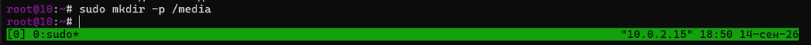

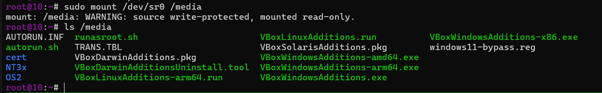

## Установка DKMS и переход в root

- Установлен DKMS для автоматической сборки модулей ядра
- Дальнейшие действия выполняются от суперпользователя

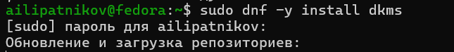

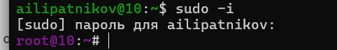

## Проверка модуля vboxguest

- Модуль `vboxguest` загружен в ядро
- Проверка: `lsmod | grep vboxguest`

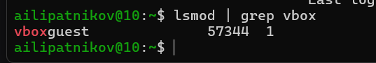

## Базовая настройка системы

- Обновление всех пакетов: `dnf update`
- SELinux переведён в режим `permissive`
- Настроена раскладка клавиатуры

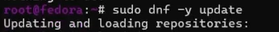

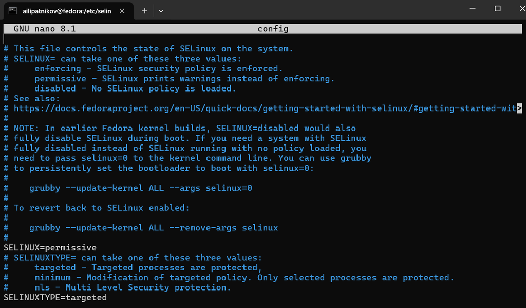

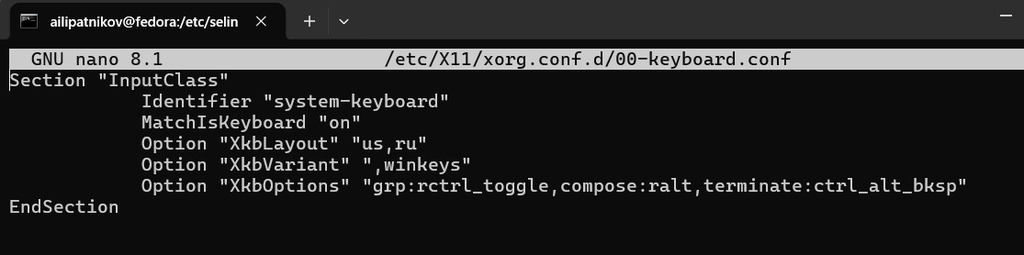

## Установка средств разработки

- Установлена группа пакетов `development-tools`
- Установлены консольные утилиты `tmux` и `mc`

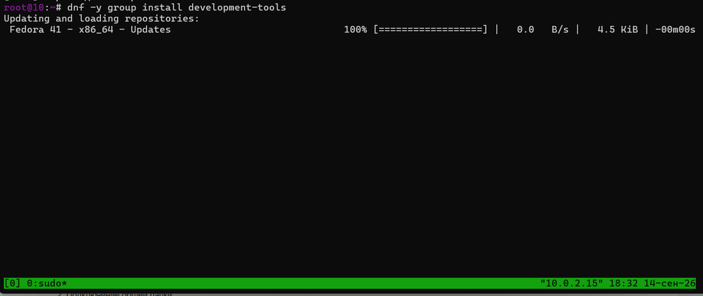

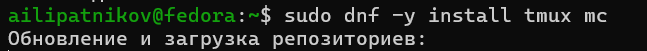

## Установка средств документации

- Установлен `pandoc` для работы с Markdown
- Установлен TeX Live для сборки PDF

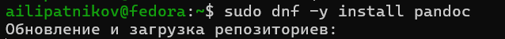

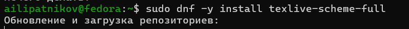

## Домашнее задание: анализ dmesg

- Проанализирован вывод `dmesg` — кольцевой буфер сообщений ядра

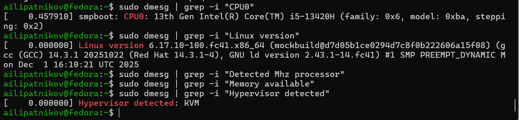

# Результаты

## Полученные данные

- Система установлена и настроена, средства разработки и документации работают

[output not shown]

# Заключение

## Главный вывод

Установленное и настроенное окружение (Fedora 41 Sway + VirtualBox) обеспечивает полный цикл работ курса: от разработки до сборки документации, — и готово к использованию в последующих лабораторных работах.